# P2 - CommUTEC

June 05, 2020

## Investigación

## Objetivo

Indagar y analizar acerca del impacto del viaje desde la residencia de un alumno hasta la universidad, resaltando su efecto en los diferentes ámbitos estudiantiles como el uso efectivo de su tiempo, su rendimiento académico.

Ésto será también relacionado con los resultados que se obtengan relacionados al estrés que puedan estar pasando.

## Muestra

Estudiantes de UTEC a partir de ciclo II

Muestreo por conveniencia: fácil acceso a nuestra unidad muestral

## Variables identificadas

| Variable | Relación con pregunta | Tipo de variable |
| --- | --- | --- |
| Edad | 1,8 | Numérica discreta |
| Cantidad de cursos que llevó el ciclo 2019-2 | 14 | Numérica discreta |
| Promedio ponderado | 11 | Numérica continua |
| Cantidad de cursos desaprobados | 10 | Numérica discreta |
| Grupo de mérito | 12 | Categórica ordinal |
| Medios de transporte | 4,16,17 | Categórica nominal |

| Variable | Relación con pregunta | Tipo de variable |
| --- | --- | --- |
| Experiencia de transporte | 3,14,15,16,17 | Categórica ordinal |
| Tiempo de transporte | 2,8,10,11,12,13,16,17 | Numérica continua |
| Actividades que hubieran hecho durante su tiempo de transporte | 6 | Categórica nominal |
| Cantidad de días con clases | 8,10,11,12,13 | Numérica discreta |
| Cantidad de horas semanales con clases | 8,10,11,12 | Numérica continua |
| Tiempo de sueño | 9,13,16 | numperica continua |
| Cantidad de días asistidos por clases de duración de tres horas a menos | 7 | Numérica continua |

| Variable | Relación con pregunta | Tipo de variable |
| --- | --- | --- |
| Horas invertidas del tiempo libre asignadas para el estudio | 12 | Numérica continua |
| Tiempo dedicado a pasatiempos | 11 | Numérica continua |
| Nivel de estrés (referencial basado en escala) | 5,9,14 | Numérica discreta |

## Escala de estrés

https://amp.milenio.com/uploads/media/2019/10/15/test-de-estres-laboral.jpg

https://amp.milenio.com/uploads/media/2019/10/15/test-de-estres-laboral-1.jpg

## Análisis de preguntas

## Archivos 1

## Archivos 2

## Archivos 3

## Descriptivas

## 1. ¿Cuál es la edad de los encuestados?

```
##    Min. 1st Qu.  Median    Mean 3rd Qu.    Max.
##   17.00   18.00   18.50   18.93   20.00   23.00
```

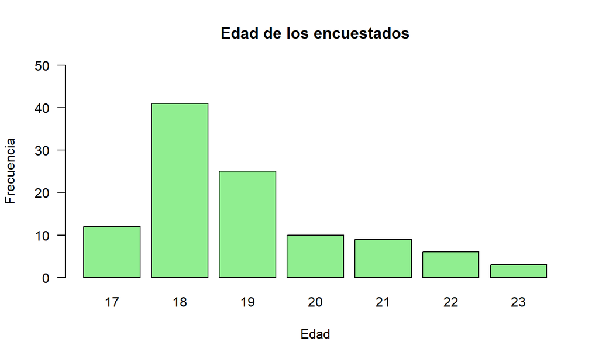

## 2. ¿Cuánto tiempo les demora a los estudiantes de UTEC llegar a la universidad desde su lugar de residencia?

```
##    Min. 1st Qu.  Median    Mean 3rd Qu.    Max.
##    2.00   22.50   40.00   47.82   60.00  150.00
```

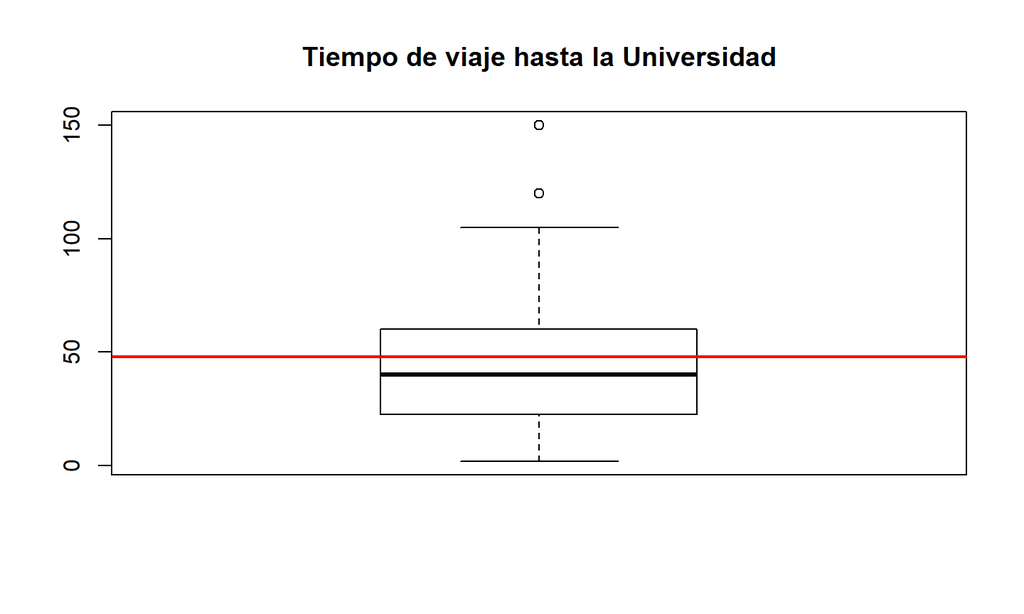

## 3. ¿Cómo califican los estudiantes la experiencia de transporte?

```
##    Min. 1st Qu.  Median    Mean 3rd Qu.    Max.
##   1.000   6.000   7.000   7.009   8.750  10.000
```

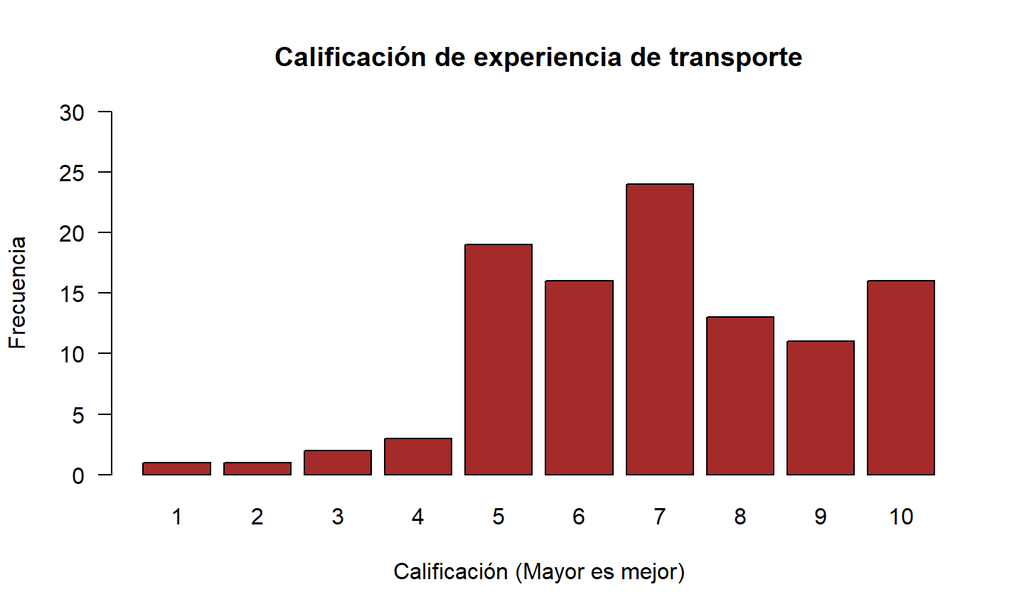

## 4. ¿Cuál es el medio de transporte más utilizado?

```
##
##           A pie           Carro     Micro/combi Otro transporte            Taxi
##            9.45           31.50           27.56            4.72           26.77
```

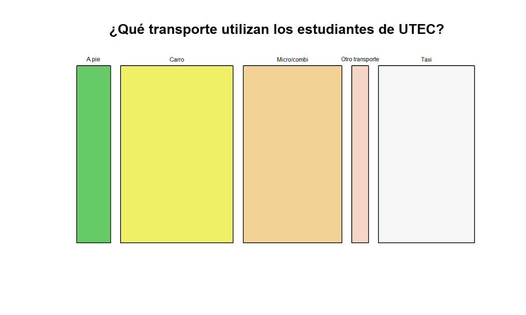

## 5. ¿Qué tan estresados se sentían los alumnos de UTEC el ciclo 2019-2?

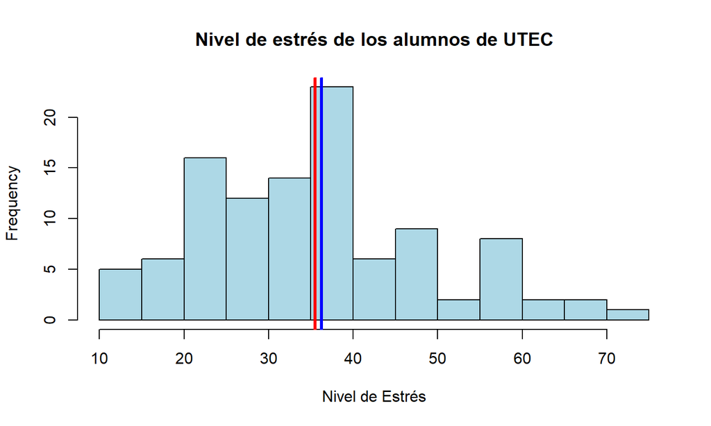

**Sin Estrés:**

```
## [1] 0.94
```

**Poco Estrés:**

```
## [1] 22.64
```

**Estrés leve:**

```
## [1] 33.02
```

**Estrés medio:**

```
## [1] 26.42
```

**Estrés alto:**

```
## [1] 12.26
```

**Estrés grave:**

```
## [1] 4.72
```

## 6. ¿Qué actividades realizarían los alumnos con el tiempo que utilizan para transportarse?

```r
round(table(actividades$Actividad)/length(medios$Actividad)*100,2)
```

```
##
##         Dormir       Estudiar Familia/amigos         Idioma           Otra
##          59.06          58.27          30.71          12.60           6.30
##    Videojuegos
##          23.62
```

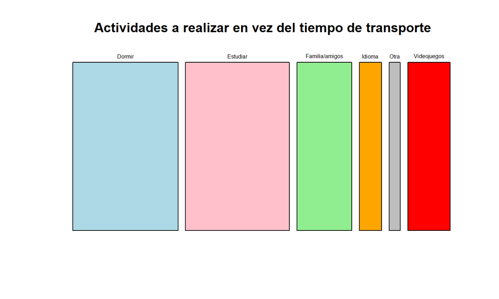

## 7. ¿Que porcentaje de alumnos tienen días con 3 horas o menos de clases?¿Para que porcentaje de alumnos el tiempo de transporte diario es mayor que el número de horas de clase en estos días (3 horas)?

```
## [1] 78.3
```

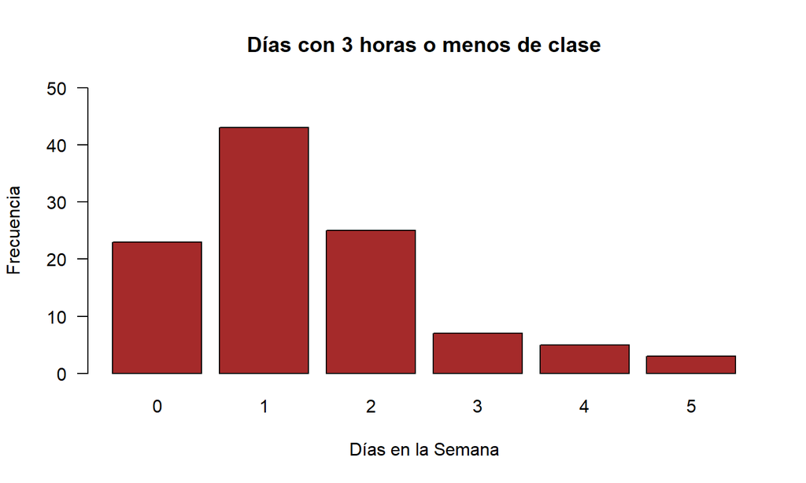

```
## [1] 6.6
```

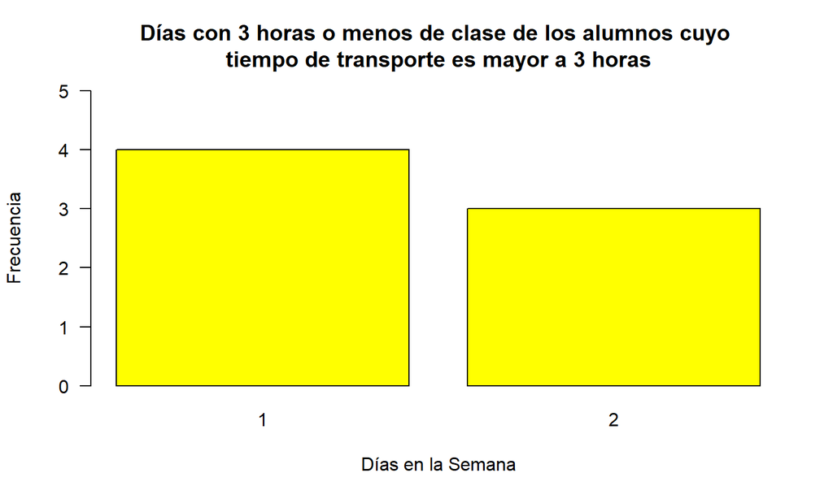

## Exploratorias

## 8. ¿Existe una relación entre la edad y el tiempo que pasan en el transporte?

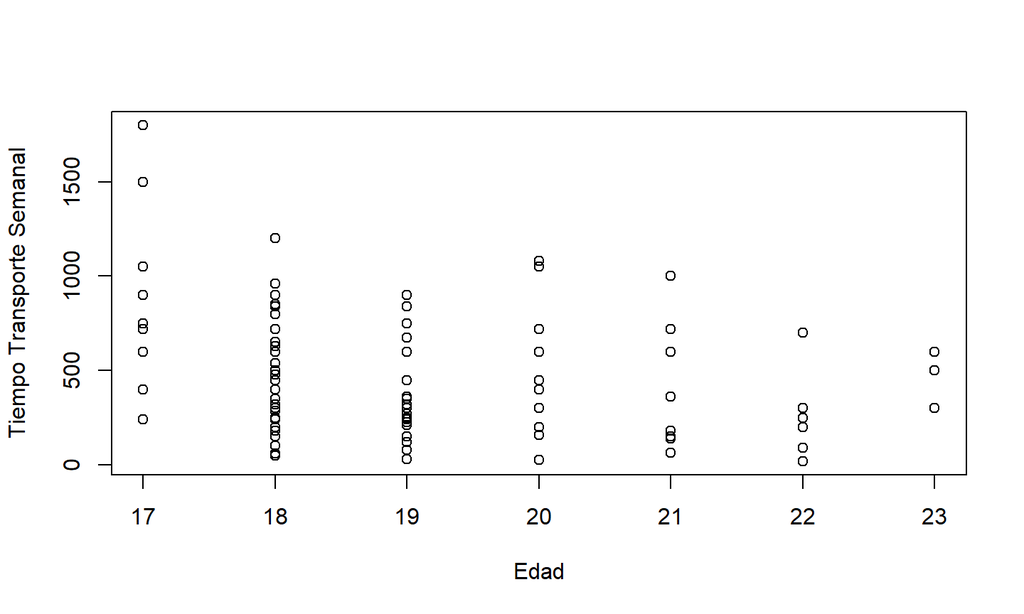

## 9. ¿Existe una relación entre el número de horas que duermen los estudiantes y el nivel de estrés que presentan?

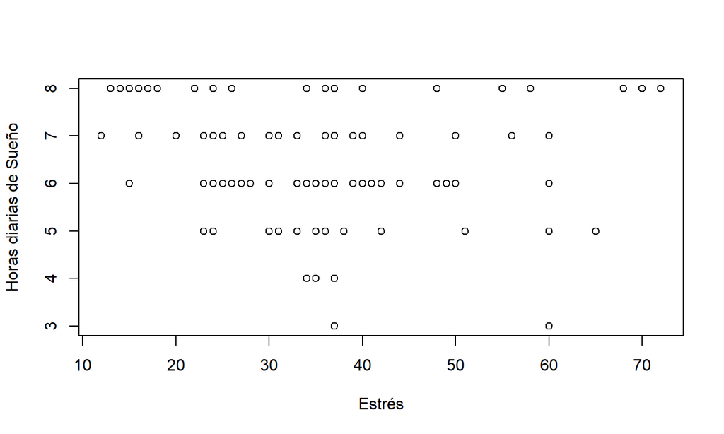

[output not shown]

## 10. ¿Existe una relación entre el tiempo que pasan en el transporte y la cantidad de cursos desaprobados?

[figure not shown]

```
## # A tibble: 3 x 3
##   NroReprobados Media_Tiempo Mediana_Tiempo
##           <dbl>        <dbl>          <dbl>
## 1             0         476.            360
## 2             1         461.            285
## 3             2         491.            600
```

## 11. ¿Existe una relación entre el tiempo de transporte y el promedio del estudiante?

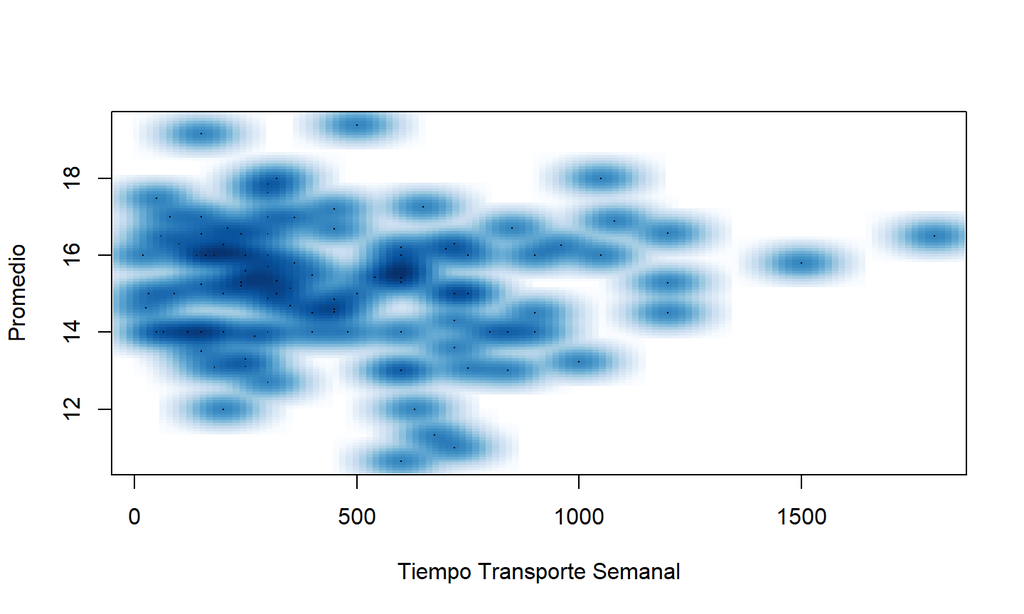

## Exploratorias –> ¿Inferenciales?

## ¿Existe alguna relación entre el grado de mérito del estudiante y las horas que se transporta semanalmente?

```
## # A tibble: 4 x 2
##   Percentil                 Mediana_Tiempo
##   <chr>                              <dbl>
## 1 1Decimo superior                     300
## 2 2Quinto superior                     360
## 3 3Tercio superior                     400
## 4 4Menos de Tercio superior            525
```

## ¿Hay una relación entre las horas que se transportan semanalmente y las horas que duermen diariamente?

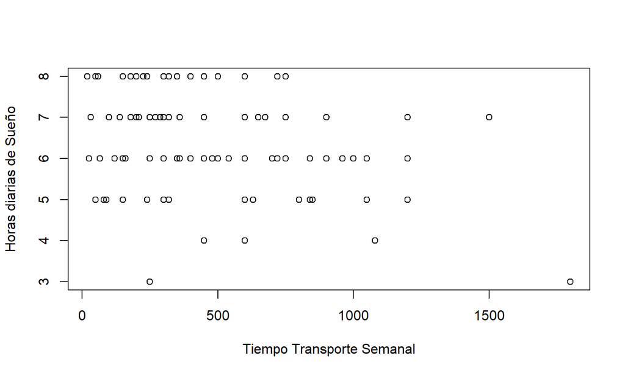

```r
DF%>% filter()%>%group_by(Tiempo_Dormir)%>%summarise(Mediana_Tiempo=median(Transporte_Semanal))->Dormir_transporte
Dormir_transporte
```

```
## # A tibble: 6 x 2
##   Tiempo_Dormir Mediana_Tiempo
##           <dbl>          <dbl>
## 1             3           1025
## 2             4            600
## 3             5            310
## 4             6            490
## 5             7            320
## 6             8            300
```

## ¿Existe una relación las horas semanales de transporte y la calificación del transporte?

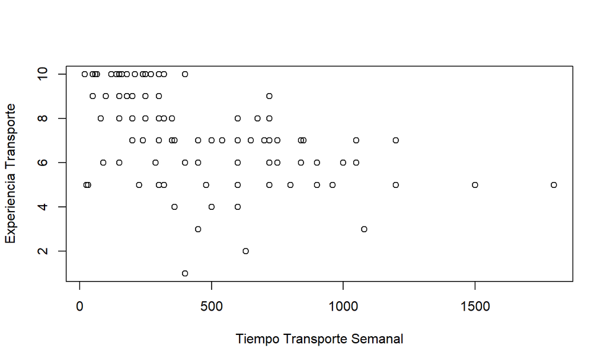

## Resumen de hipótesis

**¿Existe una relación entre la edad y el tiempo que pasan en el transporte?** Conforme la edad va aumentando,el de transporte semanal de los alumnos disminuye.

**¿Existe una relación entre el número de horas que duermen los estudiantes y el nivel de estrés que presentan?** Los estudiantes que tienen un nivel de estrés mayor, duermen menos horas diariamente.

**¿Existe alguna relación entre el tiempo que pasan en el transporte y la cantidad de cursos desaprobados del estudiante?** No existe una relación clara entre estas variables.

**Existe alguna relación entre el tiempo que pasan en el transporte y el promedio del estudiante en el ciclo 2019-2?** El tiempo de transporte no influye en el promedio ponderado del alumno.

## Resumen de hipótesis

**¿Existe alguna relación entre el grado de mérito del estudiante y las horas que se transporta semanalmente?** Mientras menos horas de transporte semanal tiene un alumno, hay una mayor probabilidad de poder encontrarse en un percentil mayor respecto a su carrera.

**¿Existe alguna relación entre las horas que se transportan semanalmente y las horas que duermen diariamente los estudiantes?** Mientras mayor sea la cantidad de tiempo de transporte semanal, menor será las horas que duermen los alumnos diariamente.

**¿Existe alguna relación las horas semanales de transporte con la calificación que le pone el alumno al transporte?** Si un alumno pasa menos tiempo transportándose, tendrá una mejor experiencia y por consiguiente, le podrá una calificación más alta que alguien que tiene una gran cantidad de horas de transporte.

## Verificación de las Hipótesis

Para verificar nuestras hipótesis primero necesitamos ampliar nuestra muestra, dado que para tener un nivel de confiabilidad del 95% y un margen de error del 7% necesitaríamos encuestar a 75 personas más aproximadamente.

Una vez que tengamos una muestra más confiable y mediante los conocimientos que aprendamos sobre como se relacionan las variables en las semanas entrantes podríamos comprobar si nuuestra hipótesis era correcta o no. Para la corroboración es necesario algún método que aprenderemos en clase, así como una mejor agrupación de los datos, por ejempo por niveles de estrés; para una mejor asociación entre las variables.

## Bibliografía

- https://gestion.pe/tendencias/lima-ciudades-peor-trafico-269483-noticia/
- https://amp.milenio.com/especiales/estres-cronico-como-identificarlo